# Battery Materials Property Analysis

## Final Project Report

### Introduction

This project explores a dataset of battery materials and their properties, focusing on understanding the relationships between chemical compositions and key performance metrics such as Capacity, Conductivity, Coulombic Efficiency, Energy, and Voltage. The analysis uses Neural Networks to identify patterns and build predictive models that could help in battery material design.

### Setup and Data Import

```python
import pandas as pd
import seaborn as sns
import numpy as np
from matplotlib import pyplot as plt
import ast
from sklearn.impute import SimpleImputer
from sklearn.model_selection import train_test_split
from sklearn.ensemble import RandomForestRegressor
from sklearn.metrics import mean_absolute_percentage_error, mean_absolute_error, mean_squared_error
import tensorflow as tf
from tensorflow import keras
from tensorflow.keras.models import Model
from tensorflow.keras.layers import Input, Dense, Dropout, BatchNormalization
from tensorflow.keras.optimizers import Adam
from sklearn.preprocessing import StandardScaler
from sklearn.metrics import r2_score, mean_squared_error
from tensorflow.keras import layers, regularizers

import os
os.makedirs('Final_Report_files', exist_ok=True)

# Set display options
pd.set_option('display.max_columns', None)
sns.set_theme(style="whitegrid")
sns.set_palette("colorblind")
plt.rcParams['figure.figsize'] = [12, 8]
plt.rcParams['font.size'] = 12
```

# Original Data

```python
orig_df = pd.read_csv("battery_merged.csv")

# Display sample data
orig_df.sample(5)
```

|  | Property | Name | Value | Raw_unit | Raw_value | Unit | Num_records | Extracted_name | DOI | Specifier | Tag | Warning | Type | Info | Title | Journal | Date | Correctness |
| --- | --- | --- | --- | --- | --- | --- | --- | --- | --- | --- | --- | --- | --- | --- | --- | --- | --- | --- |
| 61513 | Capacity | Polyvinyl alcohol | 90.0 | mAhg−1 | 90 | Gram^(-1.0) Hour^(1.0) MilliAmpere^(1.0) | 1 | [{'O': '1.0', 'H': '4.0', 'C': '2.0'}] | 10.1039/C8TA11795K | NaN | CDE | S, | NaN | NaN | A 3D flexible and robust HAPs/PVA separator pr... | Journal of Materials Chemistry A | 2019/03/19 | NaN |
| 39906 | Voltage | LixZnFe2O4 | 1.5 | V | 1.5 to 0.8 | Volt^(1.0) | 1 | [{'Li': 'x', 'Zn': '1.0', 'Fe': '2.0', 'O': '4... | 10.1016/j.jallcom.2017.06.031 | NaN | CDE | NaN | NaN | NaN | POROUSZNFE2O4NANOSPHERESANODEMATERIALSFORLIION... | Journal of Alloys and Compounds | 2017-06-07 | NaN |
| 203821 | Capacity | V2O5–CNT | 149.0 | mAhg−1 | 149 | Gram^(-1.0) Hour^(1.0) MilliAmpere^(1.0) | 1 | [{'V': '2.0', 'O': '5.0'}] | 10.1039/C5TA10414A | discharge capacity, | CDE | S, | NaN | NaN | Synthesis of a porous sheet-like V 2 O 5 –CNT ... | Journal of Materials Chemistry A | 2016/02/09 | NaN |
| 159168 | Capacity | 3Co1 / 3Mn1 / 3O2 | 135.0 | mAhg−1 | ∼ 135 | Gram^(-1.0) Hour^(1.0) MilliAmpere^(1.0) | 1 | [{'Co': '0.3333', 'Mn': '0.3333', 'O': '2.0'}] | 10.1039/C2EE21874G | specific capacity, | CDE | NaN | NaN | {'cycle_value': 'first', 'cycle_units': 'cycle... | Design criteria for electrochemical shock resi... | Energy & Environmental Science | 2012/06/20 | NaN |
| 32931 | Capacity | TiO2-II | 135.4 | mAhg−1 | 150.8 and 135.4 | Gram^(-1.0) Hour^(1.0) MilliAmpere^(1.0) | 1 | [{'Ti': '1.0', 'O': '2.0'}] | 10.1016/j.apenergy.2016.04.066 | NaN | CDE | S, | NaN | NaN | TIO2HIERARCHICALHOLLOWMICROSPHERESDIFFERENTSIZ... | Applied Energy | 2016-04-25 | NaN |

[output not shown]

# Data after cleaning

After cleaning and removing outliers in a separate script, import the clean csv file

Data cleaning process:

- Remove outliers from all target variables
- Remove all rows where the ‘correctness’ confidence is below a thrreshhold
- Resutrucutre the data to incorporate properties as features and Compounds as unique keys
- Introduce features for individual elemental compositions

```python
battery_df = pd.read_csv("clean_df.csv")
battery_df.sample(5)
```

|  | Unnamed: 0 | Name | Extracted_name | Capacity | Conductivity | Coulombic Efficiency | Energy | Voltage | parsed_name | elements_cnt | Capacity_known | Conductivity_known | Coulombic Efficiency_known | Energy_known | Voltage_known | Pd_fraction | S_fraction | Na_fraction | Ru_fraction | Zr_fraction | Cn_fraction | Hg_fraction | Be_fraction | Rb_fraction | Si_fraction | Ra_fraction | Sg_fraction | Sc_fraction | Mn_fraction | … |
| --- | --- | --- | --- | --- | --- | --- | --- | --- | --- | --- | --- | --- | --- | --- | --- | --- | --- | --- | --- | --- | --- | --- | --- | --- | --- | --- | --- | --- | --- | --- |
| 2723 | 22685 | Sodium orthosilicates | [{'Na': '4.0', 'Si': '1.0', 'O': '4.0'}] | 235.000 | NaN | NaN | 705.0 | 3.0 | [{'Na': '4.0', 'Si': '1.0', 'O': '4.0'}] | 1 | 1 | 0 | 0 | 1 | 1 | 0.0 | 0.0 | 4.0 | 0.0 | 0.0 | 0.0 | 0.0 | 0.0 | 0.0 | 1.0 | 0.0 | 0.0 | 0.0 | 0.0 | … |
| 2759 | 22850 | Terephthalic acid | [{'C': '8.0', 'O': '4.0', 'H': '6.0'}] | 428.000 | NaN | NaN | 1498.0 | 3.5 | [{'C': '8.0', 'O': '4.0', 'H': '6.0'}] | 1 | 1 | 0 | 0 | 1 | 1 | 0.0 | 0.0 | 0.0 | 0.0 | 0.0 | 0.0 | 0.0 | 0.0 | 0.0 | 0.0 | 0.0 | 0.0 | 0.0 | 0.0 | … |
| 875 | 6557 | K2LiHC55 | [{'K': '2.0', 'Li': '1.0', 'H': '1.0', 'C': '5... | NaN | NaN | NaN | NaN | 1.4 | [{'K': '2.0', 'Li': '1.0', 'H': '1.0', 'C': '5... | 1 | 0 | 0 | 0 | 0 | 1 | 0.0 | 0.0 | 0.0 | 0.0 | 0.0 | 0.0 | 0.0 | 0.0 | 0.0 | 0.0 | 0.0 | 0.0 | 0.0 | 0.0 | … |
| 2012 | 17349 | Na4C8H2O6 | [{'Na': '4.0', 'C': '8.0', 'H': '2.0', 'O': '6... | 180.000 | NaN | NaN | NaN | 2.3 | [{'Na': '4.0', 'C': '8.0', 'H': '2.0', 'O': '6... | 1 | 1 | 0 | 0 | 0 | 1 | 0.0 | 0.0 | 4.0 | 0.0 | 0.0 | 0.0 | 0.0 | 0.0 | 0.0 | 0.0 | 0.0 | 0.0 | 0.0 | 0.0 | … |
| 1302 | 10841 | Li6C28 | [{'Li': '6.0', 'C': '28.0'}] | 478.151 | NaN | NaN | NaN | NaN | [{'Li': '6.0', 'C': '28.0'}] | 1 | 1 | 0 | 0 | 0 | 0 | 0.0 | 0.0 | 0.0 | 0.0 | 0.0 | 0.0 | 0.0 | 0.0 | 0.0 | 0.0 | 0.0 | 0.0 | 0.0 | 0.0 | … |

[output not shown]

### Exploratory Data Analysis

#### Target Variable Analysis

First, let’s examine the availability of our key target variables in the dataset.

```python
# Look at the distributions of target variables where available
target_vars = ['Capacity', 'Conductivity', 'Coulombic Efficiency', 'Energy', 'Voltage']
plt.figure(figsize=(15, 10))
for i, target in enumerate(target_vars):
    plt.subplot(2, 3, i+1)
    plt.hist(battery_df[target].dropna(), bins=20, color='steelblue', alpha=0.7)
    plt.title(f'Distribution of {target}', fontsize=14)
    plt.xlabel(target, fontsize=12)
    plt.ylabel('Count', fontsize=12)
plt.tight_layout()
plt.savefig('target_distributions.png')
plt.close() #plt.show()
```

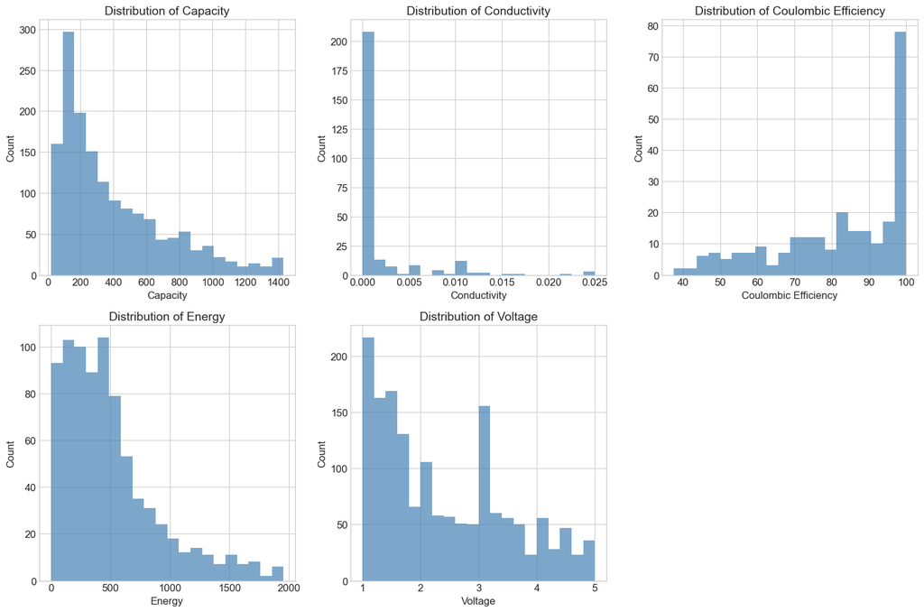

png

```python
target_vars = ['Capacity', 'Conductivity', 'Coulombic Efficiency', 'Energy', 'Voltage']
missing_percentages = {target: (battery_df[target].isna().sum() / len(battery_df) * 100)
                      for target in target_vars}

# Sort by missing percentage
sorted_missing = dict(sorted(missing_percentages.items(), key=lambda x: x[1], reverse=True))

# Create figure with two subplots
fig, (ax1, ax2) = plt.subplots(1, 2, figsize=(15, 6))

# Bar chart of missing percentages
colors = plt.cm.Reds(np.linspace(0.6, 0.9, len(sorted_missing)))
ax1.bar(sorted_missing.keys(), sorted_missing.values(), color=colors)
ax1.set_xlabel('Battery Property', fontsize=12)
ax1.set_ylabel('Missing Data (%)', fontsize=12)
ax1.set_title('Missing Values in Battery Properties', fontsize=14, fontweight='bold')
ax1.set_ylim(0, 100)
ax1.grid(axis='y', alpha=0.3)

# Add text labels to bars
for i, (target, pct) in enumerate(sorted_missing.items()):
    ax1.text(i, pct + 2, f'{pct:.1f}%', ha='center', fontweight='bold')

# Heatmap showing available vs missing data
data_availability = pd.DataFrame({
    'Available': [100 - pct for pct in sorted_missing.values()],
    'Missing': list(sorted_missing.values())
}, index=sorted_missing.keys())

sns.heatmap(data_availability, annot=True, fmt='.1f', cmap='RdYlGn_r',
           cbar_kws={'label': 'Percentage (%)'}, ax=ax2)
ax2.set_title('Data Availability for Battery Properties', fontsize=14, fontweight='bold')

plt.tight_layout()
plt.savefig('missing_data_visualization.png', dpi=300, bbox_inches='tight')
plt.close() #plt.show()
```

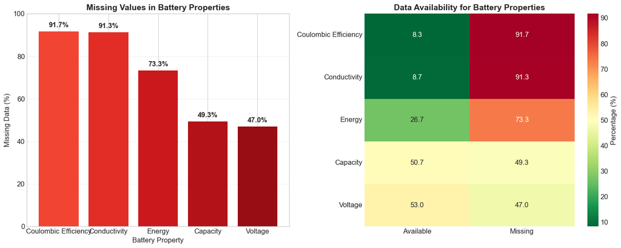

png

# Visualization reveals significant data sparsity:

- Coulombic Efficiency: 91.7% missing
- Conductivity: 91.3% missing
- Energy: 73.3% missing
- Capacity: 49.3% missing
- Voltage: 47.0% missing

This sparsity will significantly impact our modeling approach, particularly for Coulombic Efficiency and Conductivity where over 90% of the data is missing.

Due to this we chose to drop the two from our targets instead only focusing on Energy, Capacity and Voltage

#### Dataset Overview

```python
column_list = list(battery_df.columns)
print("Dataset columns:")
print(column_list)
```

```
Dataset columns:
['Unnamed: 0', 'Name', 'Extracted_name', 'Capacity', 'Conductivity', 'Coulombic Efficiency', 'Energy', 'Voltage', 'parsed_name', 'elements_cnt', 'Capacity_known', 'Conductivity_known', 'Coulombic Efficiency_known', 'Energy_known', 'Voltage_known', 'Pd_fraction', 'S_fraction', 'Na_fraction', 'Ru_frac…
```

[output not shown]

The dataset now contains information about material names, target properties, and a large number of element fractions representing the chemical composition of each material.

### Relationship Analysis

Explore the relationships between:

- element compositions and battery properties.

```python
# Extract element fraction columns
element_cols = [col for col in battery_df.columns if '_fraction' in col]

# Calculate correlation between elements and targets where data is available
correlation_results = {}
for target in target_vars:
    # Get correlation for each element with the target
    valid_data = battery_df[~battery_df[target].isna()]
    if len(valid_data) > 0:  # Only if we have some data
        correlations = []
        for elem in element_cols:
            if valid_data[elem].nunique() > 1:  # Only if the element has variation
                corr = np.corrcoef(valid_data[elem], valid_data[target])[0, 1]
                correlations.append((elem, corr))
        # Sort by absolute correlation
        correlations.sort(key=lambda x: abs(x[1]), reverse=True)
        correlation_results[target] = correlations[:10]  # Top 10 correlations

# Create a visualization of top element correlations for each target
plt.figure(figsize=(16, 12))
# For each target property, show top 5 correlations
for i, target in enumerate(target_vars):
    if target not in correlation_results:
        continue
    # Get top 5 correlations by absolute value
    top_correlations = correlation_results[target][:5]
    # Extract elements and correlation values
    elements = [item[0].replace('_fraction', '') for item in top_correlations]
    correlations = [item[1] for item in top_correlations]
    # Create subplot for this target
    plt.subplot(2, 3, i+1)
    # Colors based on positive/negative correlation
    colors = ['#2C7BB6' if c < 0 else '#D7191C' for c in correlations]
    # Plot horizontal bar chart
    bars = plt.barh(elements, correlations, color=colors)
    # Add values to the end of each bar
    for bar in bars:
        width = bar.get_width()
        label_x_pos = width + 0.01 if width > 0 else width - 0.07
        plt.text(label_x_pos, bar.get_y() + bar.get_height()/2,
                f'{width:.3f}', va='center')
    plt.axvline(x=0, color='black', linestyle='-', alpha=0.3)
    plt.title(f'Top Element Correlations with {target}')
    plt.xlabel('Correlation Coefficient')
    plt.ylabel('Elements')
    plt.xlim(-0.3, 0.3)
plt.tight_layout()
plt.savefig('element_correlations.png')
plt.close() #plt.show()
```

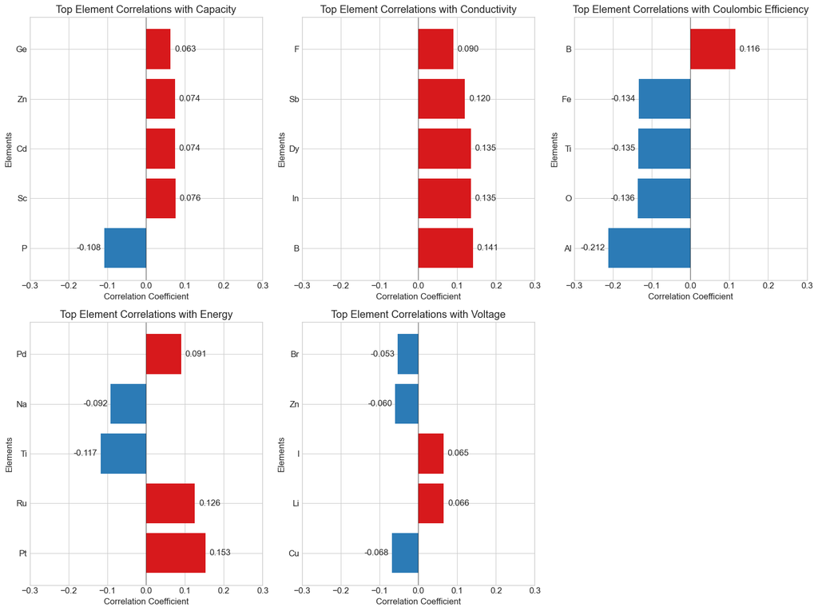

png

The interactions between individual elements and the target variables are very weak with the largest being |.153| between Energy an Pt among the three chosen target variables

```python
for target in target_vars:
    if target not in correlation_results:
        continue

    # Get top 10 correlating elements
    top_elements = [elem[0] for elem in correlation_results[target]]

    # Create a subset of the data with target and top elements
    valid_data = battery_df[~battery_df[target].isna()]
    corr_df = valid_data[[target] + top_elements]

    # Calculate correlation matrix
    corr_matrix = corr_df.corr()

    # Create heatmap
    plt.figure(figsize=(10, 8))
    mask = np.triu(np.ones_like(corr_matrix, dtype=bool))
    sns.heatmap(corr_matrix, mask=mask, annot=True, fmt='.2f', cmap='coolwarm',
                square=True, linewidths=.5, cbar_kws={"shrink": .8})
    plt.title(f'Correlation Heatmap: {target} vs Top Elements', fontsize=16)
    plt.tight_layout()
    plt.savefig(f'{target}_element_correlation_heatmap.png')
    plt.close() #plt.show()
```

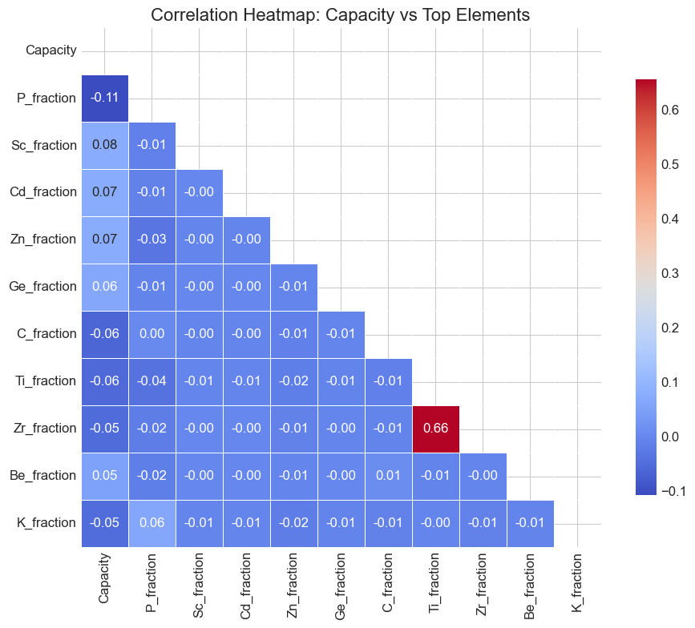

png

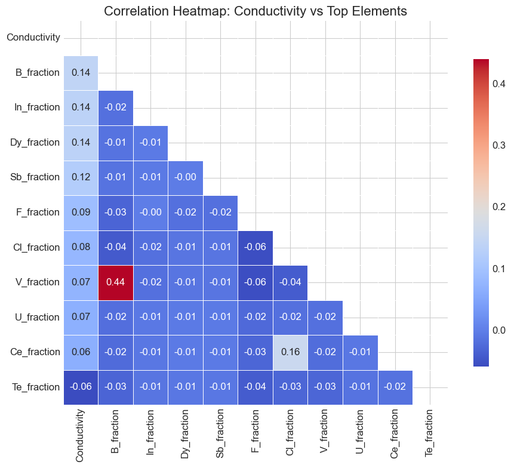

png

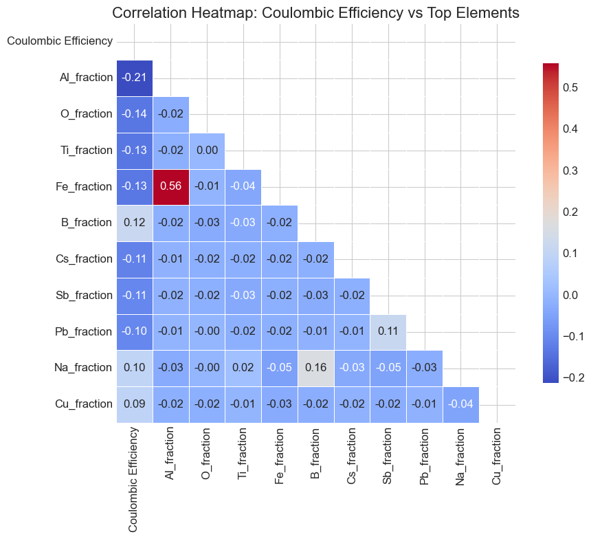

png

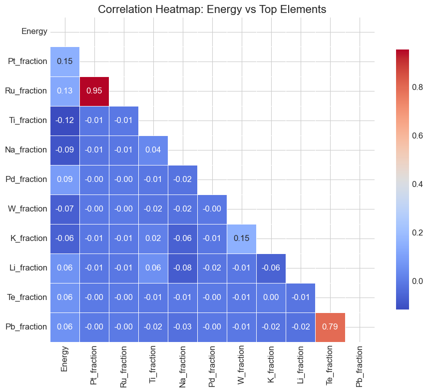

png

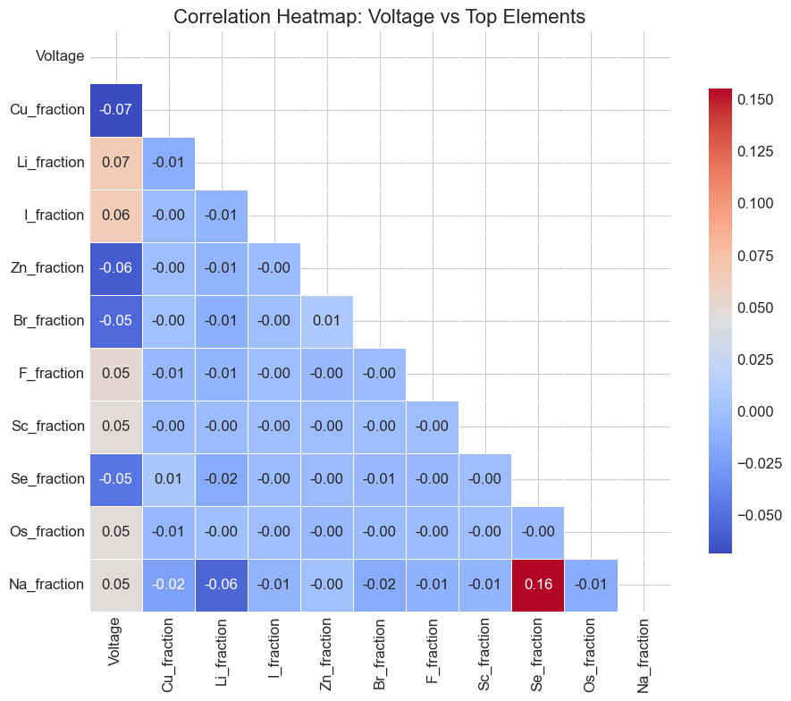

png

- correlations between the target variables themselves:

```python
valid_targets = battery_df[target_vars].dropna(how='all')
if len(valid_targets) > 0:
    target_corr = valid_targets.corr()
    plt.figure(figsize=(10, 8))
    mask = np.triu(np.ones_like(target_corr, dtype=bool))
    sns.heatmap(target_corr, mask=mask, annot=True, fmt='.2f', cmap='coolwarm',
                square=True, linewidths=.5, cbar_kws={"shrink": .8})
    plt.title('Correlation Between Target Variables', fontsize=16)
    plt.tight_layout()
    plt.savefig('target_correlations.png')
    plt.close() #plt.show()

    print("\nCorrelation between target variables:")
    print(target_corr)
```

```
Correlation between target variables:
                      Capacity  Conductivity  Coulombic Efficiency    Energy  \
Capacity              1.000000      0.059616             -0.301985  0.406381
Conductivity          0.059616      1.000000             -0.029675  0.040337
Coulombic Efficiency -0.301985     -0.029675              1.000000 -0.110273
Energy                0.406381      0.040337             -0.110273  1.000000
Voltage              -0.372989     -0.160456              0.204989  0.090613

                       Voltage
Capacity             -0.372989
Conductivity         -0.160456
Coulombic Efficiency  0.204989
Energy                0.090613
Voltage               1.000000
```

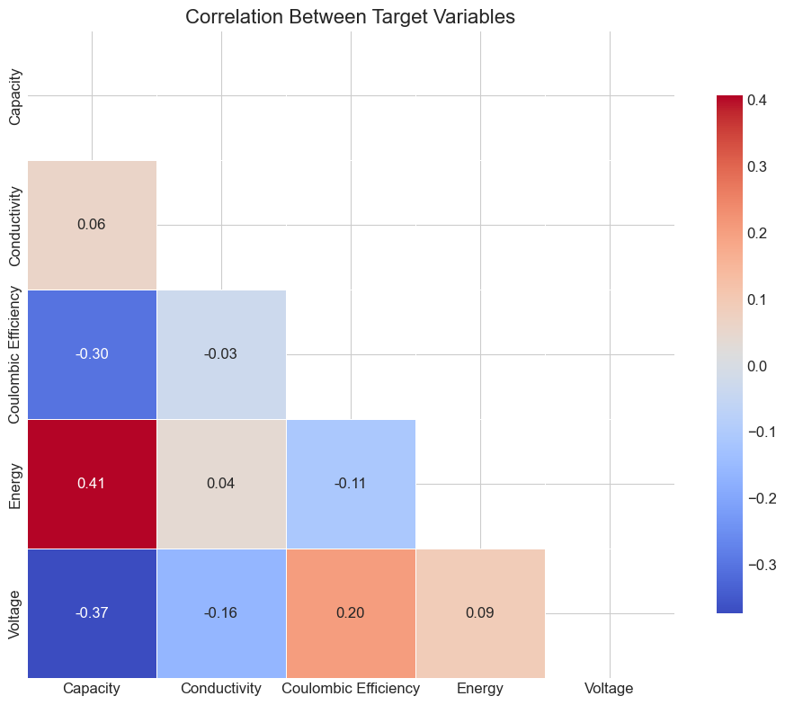

png

[output not shown]

### Baseline Model Development

```python
def train_baseline_nn(X, y, test_size=0.2, random_state=42):
    """Train a simple neural network as baseline"""
    # Split data
    X_train, X_test, y_train, y_test = train_test_split(
        X, y, test_size=test_size, random_state=random_state
    )

    # Standardize features and target variables to ensure that the model trains effectively without bias toward larger scale variables.
    X_scaler = StandardScaler()
    X_train_scaled = X_scaler.fit_transform(X_train)
    X_test_scaled = X_scaler.transform(X_test)

    y_scaler = StandardScaler()
    y_train_scaled = y_scaler.fit_transform(y_train.values.reshape(-1, 1)).flatten()
    y_test_scaled = y_scaler.transform(y_test.values.reshape(-1, 1)).flatten()

    # Create simple model
    model = keras.Sequential([
        layers.Dense(64, activation='relu', input_shape=(X_train.shape[1],)),
        layers.Dense(32, activation='relu'),
        layers.Dense(1)
    ])

    # Compile model
    model.compile(optimizer='adam', loss='mse', metrics=['mae'])

    # Train model
    history = model.fit(
        X_train_scaled, y_train_scaled,
        validation_split=0.2,
        epochs=100,
        batch_size=32,
        callbacks=[
            # Use early stopping to prevent overfitting by stopping training when the validation loss does not improve for 20 epochs
            keras.callbacks.EarlyStopping(
                monitor='val_loss', patience=20, restore_best_weights=True
            )
        ],
        verbose=0
    )

    # Evaluate model
    y_pred_scaled = model.predict(X_test_scaled, verbose=0).flatten()
    y_pred = y_scaler.inverse_transform(y_pred_scaled.reshape(-1, 1)).flatten()

    # Calculate metrics
    mse = mean_squared_error(y_test, y_pred)
    rmse = np.sqrt(mse)
    r2 = r2_score(y_test, y_pred)

    # Return results
    return {
        'model': model,
        'history': history,
        'X_scaler': X_scaler,
        'y_scaler': y_scaler,
        'y_test': y_test,
        'y_pred': y_pred,
        'mse': mse,
        'rmse': rmse,
        'r2': r2,
        'train_size': len(X_train),
        'test_size': len(X_test)
    }
# Focus on targets with more data available
baseline_target_vars = ['Capacity', 'Energy', 'Voltage']

# Train baseline models
baseline_models = {}
for target in baseline_target_vars:
    print(f"\nTraining baseline model for {target}...")
    # Get valid data for this target
    mask = ~battery_df[target].isna()
    X = battery_df[element_cols][mask]
    y = battery_df[target][mask]

    # Train model
    result = train_baseline_nn(X, y)
    baseline_models[target] = result

    # Print performance metrics
    print(f" Samples: {result['train_size']} train, {result['test_size']} test")
    print(f" RMSE: {result['rmse']:.4f}")
    print(f" R²: {result['r2']:.4f}")
```

```
Training baseline model for Capacity...
 Samples: 1227 train, 307 test
 RMSE: 608.0279
 R²: -3.1549

Training baseline model for Energy...
 Samples: 645 train, 162 test
 RMSE: 6193.1413
 R²: -273.0922

Training baseline model for Voltage...
 Samples: 1282 train, 321 test
 RMSE: 23.6095
 R²: -469.7097
```

```python
plt.figure(figsize=(15, 12))
for i, target in enumerate(baseline_target_vars):
    plt.subplot(3, 1, i+1)
    plt.plot(baseline_models[target]['history'].history['loss'], label='Training Loss')
    plt.plot(baseline_models[target]['history'].history['val_loss'], label='Validation Loss')
    plt.title(f'Baseline Model Learning Curves: {target}', fontsize=14)
    plt.xlabel('Epochs')
    plt.ylabel('Loss')
    plt.legend()

    # Add metrics as text
    plt.text(0.05, 0.85, f"R² = {baseline_models[target]['r2']:.3f}",
             transform=plt.gca().transAxes)
    plt.text(0.05, 0.78, f"RMSE = {baseline_models[target]['rmse']:.3f}",
             transform=plt.gca().transAxes)

plt.tight_layout()
plt.savefig('baseline_learning_curves.png', dpi=300)
plt.close() #plt.show()
```

[figure not shown]

png

- The model is overfitting which means we need to reduce the number of layers
- The lack of data is really hurting the model and we need to find ways to compensate for this

### Feature Engineering

The correlations between elemental compositions and target properties are relatively weak, suggesting we need to rely on feature engineering to improve predictive power.

#### Data Cleaning

```python
# Set negative fractions to zero because negative composition is not physically possible
for col in element_cols:
    battery_df.loc[battery_df[col] < 0, col] = 0
    # Replace negative values with 0
    # Cap values at 1 since element fractions must be within the range [0, 1]
    battery_df.loc[battery_df[col] > 1, col] = 1


# Recalculate element count
battery_df['element_count'] = battery_df[element_cols].sum(axis=1)

# Print element count statistics
print("\nElement count statistics:")
print(battery_df['element_count'].describe())

# Print the number of compounds with each element count
element_count_dist = battery_df['element_count'].value_counts().sort_index()
print("\nDistribution of number of elements per compound:")
print(element_count_dist)
```

```
Element count statistics:
count    3027.000000
mean        3.092831
std         0.977762
min         0.000000
25%         2.000000
50%         3.000000
75%         4.000000
max         9.000000
Name: element_count, dtype: float64

Distribution of number of elements per compound:
element_count
0.0       1
1.0      10
2.0     929
3.0    1147
4.0     693
5.0     212
6.0      27
7.0       6
8.0       1
9.0       1
Name: count, dtype: int64
```

[output not shown]

#### Materials Science-Based Features

To improve our models, we’ll add features based on materials science principles:

- avg electronegativity
- avg atomic radius
- avg ionization energy
- element diversity
- element count (from previous cell)
- valence electors
- redox potential
- element interatioons

```python
elemental_properties = {
    'electronegativity': {
        'H': 2.20, 'Li': 0.98, 'Be': 1.57, 'B': 2.04, 'C': 2.55, 'N': 3.04, 'O': 3.44, 'F': 3.98,
        'Na': 0.93, 'Mg': 1.31, 'Al': 1.61, 'Si': 1.90, 'P': 2.19, 'S': 2.58, 'Cl': 3.16,
        'K': 0.82, 'Ca': 1.00, 'Sc': 1.36, 'Ti': 1.54, 'V': 1.63, 'Cr': 1.66, 'Mn': 1.55,
        'Fe': 1.83, 'Co': 1.88, 'Ni': 1.91, 'Cu': 1.90, 'Zn': 1.65, 'Ga': 1.81, 'Ge': 2.01,
        'As': 2.18, 'Se': 2.55, 'Br': 2.96, 'Rb': 0.82, 'Sr': 0.95, 'Y': 1.22, 'Zr': 1.33,
        'Nb': 1.6, 'Mo': 2.16, 'Tc': 1.9, 'Ru': 2.2, 'Rh': 2.28, 'Pd': 2.20, 'Ag': 1.93,
        'Cd': 1.69, 'In': 1.78, 'Sn': 1.96, 'Sb': 2.05, 'Te': 2.1, 'I': 2.66, 'Cs': 0.79,
        'Ba': 0.89, 'La': 1.1, 'Ce': 1.12, 'Pr': 1.13, 'Nd': 1.14, 'Sm': 1.17, 'Eu': 1.2,
        'Gd': 1.2, 'Tb': 1.1, 'Dy': 1.22, 'Ho': 1.23, 'Er': 1.24, 'Tm': 1.25, 'Yb': 1.1,
        'Lu': 1.27, 'Hf': 1.3, 'Ta': 1.5, 'W': 2.36, 'Re': 1.9, 'Os': 2.2, 'Ir': 2.20,
        'Pt': 2.28, 'Au': 2.54, 'Hg': 2.00, 'Tl': 1.62, 'Pb': 2.33, 'Bi': 2.02, 'Po': 2.0,
        'At': 2.2, 'Ra': 0.9, 'Ac': 1.1, 'Th': 1.3, 'Pa': 1.5, 'U': 1.38, 'Np': 1.36, 'Pu': 1.28,
        'Am': 1.13, 'Cm': 1.28, 'Es': 1.3
    },
    'atomic_radius': {
        'H': 25, 'Li': 145, 'Be': 105, 'B': 85, 'C': 70, 'N': 65, 'O': 60, 'F': 50,
        'Na': 180, 'Mg': 150, 'Al': 125, 'Si': 110, 'P': 100, 'S': 100, 'Cl': 100,
        'K': 220, 'Ca': 180, 'Sc': 160, 'Ti': 140, 'V': 135, 'Cr': 140, 'Mn': 140,
        'Fe': 140, 'Co': 135, 'Ni': 135, 'Cu': 135, 'Zn': 135, 'Ga': 130, 'Ge': 125,
        'As': 115, 'Se': 115, 'Br': 115, 'Rb': 235, 'Sr': 200, 'Y': 180, 'Zr': 155,
        'Nb': 145, 'Mo': 145, 'Tc': 135, 'Ru': 130, 'Rh': 135, 'Pd': 140, 'Ag': 160,
        'Cd': 155, 'In': 155, 'Sn': 145, 'Sb': 145, 'Te': 140, 'I': 140, 'Cs': 260,
        'Ba': 215, 'La': 195, 'Ce': 185, 'Pr': 185, 'Nd': 185, 'Sm': 185, 'Eu': 185,
        'Gd': 180, 'Tb': 175, 'Dy': 175, 'Ho': 175, 'Er': 175, 'Tm': 175, 'Yb': 175,
        'Lu': 175, 'Hf': 155, 'Ta': 145, 'W': 135, 'Re': 135, 'Os': 130, 'Ir': 135,
        'Pt': 135, 'Au': 135, 'Hg': 150, 'Tl': 190, 'Pb': 180, 'Bi': 160, 'Po': 190,
        'At': 150, 'Ra': 215, 'Ac': 195, 'Th': 180, 'Pa': 180, 'U': 175, 'Np': 175,
        'Pu': 175, 'Am': 175, 'Cm': 180, 'Es': 180
    },
    'ionization_energy': {
        'H': 1312, 'Li': 520, 'Be': 900, 'B': 801, 'C': 1086, 'N': 1402, 'O': 1314, 'F': 1681,
        'Na': 496, 'Mg': 738, 'Al': 578, 'Si': 787, 'P': 1012, 'S': 1000, 'Cl': 1251,
        'K': 419, 'Ca': 590, 'Sc': 633, 'Ti': 659, 'V': 651, 'Cr': 653, 'Mn': 717,
        'Fe': 759, 'Co': 760, 'Ni': 737, 'Cu': 746, 'Zn': 906, 'Ga': 579, 'Ge': 762,
        'As': 947, 'Se': 941, 'Br': 1140, 'Rb': 403, 'Sr': 550, 'Y': 600, 'Zr': 640,
        'Nb': 652, 'Mo': 684, 'Tc': 702, 'Ru': 710, 'Rh': 720, 'Pd': 805, 'Ag': 731,
        'Cd': 868, 'In': 558, 'Sn': 709, 'Sb': 834, 'Te': 869, 'I': 1008, 'Cs': 376,
        'Ba': 503, 'La': 538, 'Ce': 528, 'Pr': 523, 'Nd': 530, 'Sm': 544, 'Eu': 547,
        'Gd': 592, 'Tb': 564, 'Dy': 573, 'Ho': 581, 'Er': 589, 'Tm': 597, 'Yb': 603,
        'Lu': 524, 'Hf': 659, 'Ta': 761, 'W': 770, 'Re': 760, 'Os': 840, 'Ir': 880,
        'Pt': 870, 'Au': 890, 'Hg': 1007, 'Tl': 589, 'Pb': 716, 'Bi': 703, 'Po': 812,
        'At': 890, 'Ra': 509, 'Ac': 499, 'Th': 587, 'Pa': 568, 'U': 598, 'Np': 605,
        'Pu': 585, 'Am': 578, 'Cm': 581, 'Es': 619
    }
}

# Create weighted average functions for each property
def add_weighted_properties(df, element_cols, elemental_properties):
    """Add weighted average properties based on elemental composition"""
    # For each property, create a new column with weighted average
    for prop_name, prop_values in elemental_properties.items():
        # Initialize column with zeros
        df[f'avg_{prop_name}'] = 0.0
        # For each element
        for element in prop_values.keys():
            # Find corresponding column
            col_name = f'{element}_fraction'
            if col_name in element_cols:
                # Add weighted contribution
                df[f'avg_{prop_name}'] += df[col_name] * prop_values[element]
    return df

# Calculate Shannon entropy to measure element diversity
def calculate_shannon_entropy(row, element_cols):
    """Calculate diversity of elements using Shannon entropy"""
    fractions = [row[col] for col in element_cols]
    # Filter out zeros and normalize
    fractions = [f for f in fractions if f > 0]
    if not fractions:
        return 0
    total = sum(fractions)
    fractions = [f/total for f in fractions]
    return -sum(f * np.log(f) for f in fractions)

# Add weighted properties
df_enhanced = add_weighted_properties(battery_df, element_cols, elemental_properties)

# Add element diversity
df_enhanced['element_diversity'] = df_enhanced.apply(
    lambda row: calculate_shannon_entropy(row, element_cols), axis=1
)

# Print the features we've engineered
print("Engineered features summary:")
engineered_features = ['avg_electronegativity', 'avg_atomic_radius', 'avg_ionization_energy',
                       'element_diversity', 'element_count']
print(df_enhanced[engineered_features].describe())
```

```
Engineered features summary:
       avg_electronegativity  avg_atomic_radius  avg_ionization_energy  \
count            3027.000000        3027.000000            3027.000000
mean                6.810469         339.150975            2883.903865
std                 2.621334         120.036577            1154.966243
min                 0.000000           0.000000               0.000000
25%                 4.770000         255.000000            2012.000000
50%                 6.610000         330.000000            2709.000000
75%                 8.220000         415.000000            3533.500000
max                19.150000        1265.000000            8342.000000

       element_diversity  element_count
count        3027.000000    3027.000000
mean            1.080368       3.092831
std             0.313351       0.977762
min            -0.000000       0.000000
25%             0.693147       2.000000
50%             1.098612       3.000000
75%             1.386294       4.000000
max             2.197225       9.000000
```

# Correlation analysis

```python
correlation_results = {}
for target in target_vars:
    # Get correlation for each feature with the target
    valid_data = df_enhanced[~df_enhanced[target].isna()]
    if len(valid_data) > 0:  # Only if we have some data
        correlations = []
        for feature in engineered_features:
            corr = np.corrcoef(valid_data[feature], valid_data[target])[0, 1]
            correlations.append((feature, corr))
        correlation_results[target] = correlations
# Print the correlations of engineered features with targets
for target, correlations in correlation_results.items():
    print(f"\nCorrelations with {target}:")
    for feature, corr in correlations:
        print(f"{feature}: {corr:.4f}")
```

```
Correlations with Capacity:
avg_electronegativity: -0.2061
avg_atomic_radius: -0.2334
avg_ionization_energy: -0.2013
element_diversity: -0.2533
element_count: -0.2516

Correlations with Conductivity:
avg_electronegativity: 0.0477
avg_atomic_radius: -0.0938
avg_ionization_energy: 0.0562
element_diversity: -0.0063
element_count: -0.0050

Correlations with Coulombic Efficiency:
avg_electronegativity: 0.0715
avg_atomic_radius: 0.1067
avg_ionization_energy: 0.0685
element_diversity: 0.0858
element_count: 0.0923

Correlations with Energy:
avg_electronegativity: -0.0588
avg_atomic_radius: -0.1736
avg_ionization_energy: -0.0672
element_diversity: -0.1311
element_count: -0.1298

Correlations with Voltage:
avg_electronegativity: 0.2001
avg_atomic_radius: 0.1539
avg_ionization_energy: 0.2080
element_diversity: 0.2151
element_count: 0.2300
```

```python
for target in target_vars:
    if target in correlation_results:
        # Create a DataFrame with the target and engineered features
        valid_data = df_enhanced[~df_enhanced[target].isna()]
        features_df = valid_data[[target] + engineered_features]

        # Calculate correlation matrix
        corr_matrix = features_df.corr()

        # Create heatmap
        plt.figure(figsize=(10, 8))
        mask = np.triu(np.ones_like(corr_matrix, dtype=bool))
        sns.heatmap(corr_matrix, mask=mask, annot=True, fmt='.2f', cmap='coolwarm',
                   square=True, linewidths=.5, cbar_kws={"shrink": .8})
        plt.title(f'Correlation Heatmap: {target} vs Engineered Features', fontsize=16)
        plt.tight_layout()
        plt.savefig(f'{target}_engineered_features_heatmap.png')
        plt.close() #plt.show()
```

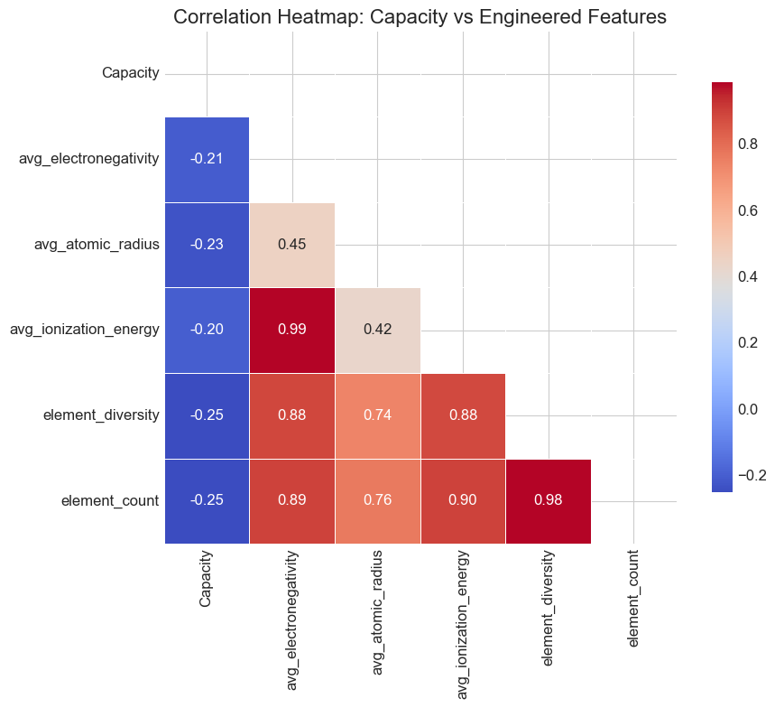

png

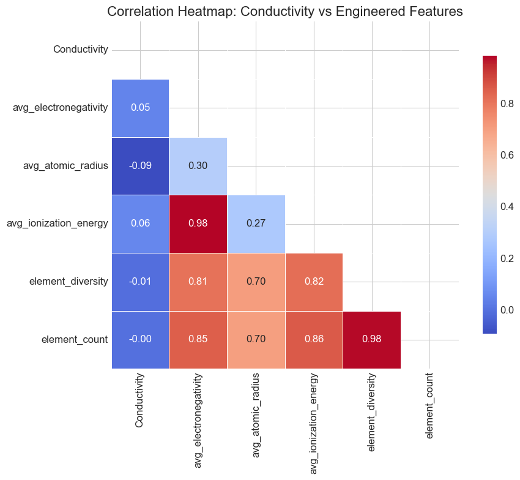

png

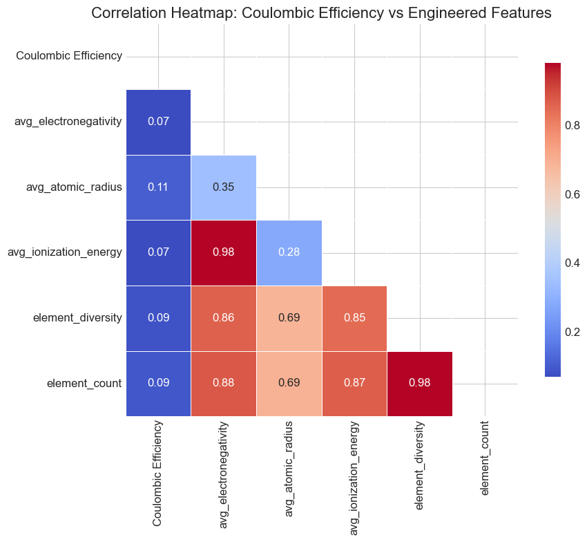

png

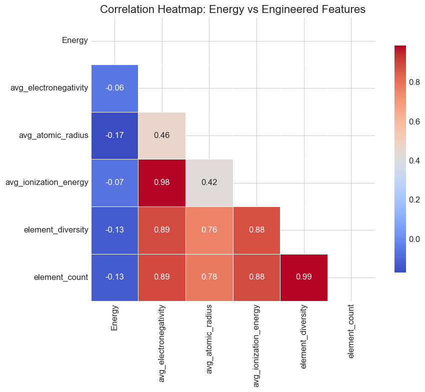

png

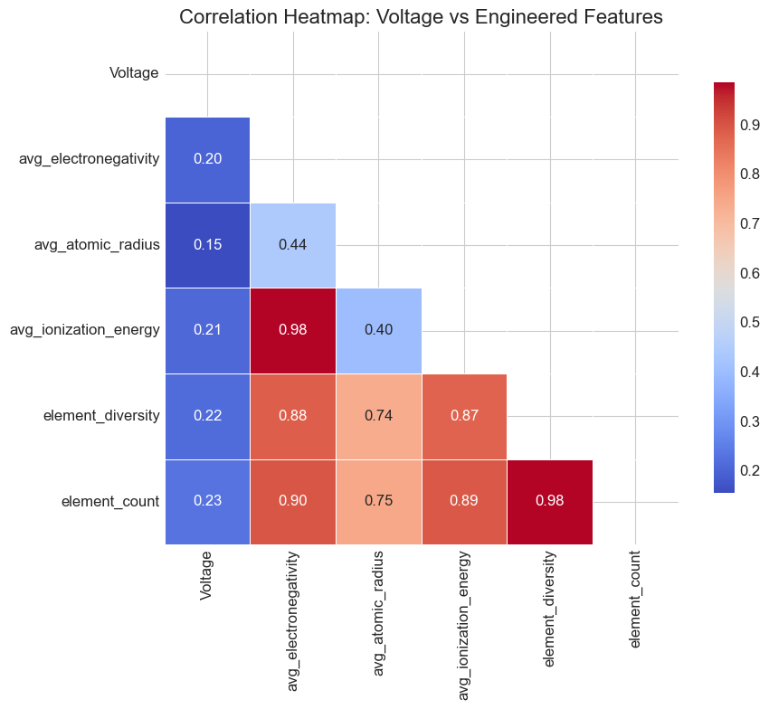

png

Engineered features have higher correlation than elemental compositoins. Let’s add more sophisticated fetaures

```python
def add_advanced_features(df, element_cols, elemental_properties):
    # 1. Calculate electronegativity differences (related to bond polarity)
    df['max_electronegativity_diff'] = 0.0

    # For each compound, find the maximum electronegativity difference
    for compound_idx in df.index:
        present_elements = []
        electronegativities = []

        # Find elements present in this compound
        for element in elemental_properties['electronegativity'].keys():
            col = f'{element}_fraction'
            if col in element_cols and df.loc[compound_idx, col] > 0.01:  # Element is present
                present_elements.append(element)
                electronegativities.append(elemental_properties['electronegativity'][element])

        # Calculate max difference if we have at least 2 elements
        if len(electronegativities) >= 2:
            df.loc[compound_idx, 'max_electronegativity_diff'] = max(electronegativities) - min(electronegativities)

    # 2. Add average valence electron count (important for electrical properties)
    valence_electrons = {
        'H': 1, 'Li': 1, 'Na': 1, 'K': 1, 'Rb': 1, 'Cs': 1,  # Group 1
        'Be': 2, 'Mg': 2, 'Ca': 2, 'Sr': 2, 'Ba': 2,  # Group 2
        'B': 3, 'Al': 3, 'Ga': 3, 'In': 3, 'Tl': 3,  # Group 13
        'C': 4, 'Si': 4, 'Ge': 4, 'Sn': 4, 'Pb': 4,  # Group 14
        'N': 5, 'P': 5, 'As': 5, 'Sb': 5, 'Bi': 5,  # Group 15
        'O': 6, 'S': 6, 'Se': 6, 'Te': 6, 'Po': 6,  # Group 16
        'F': 7, 'Cl': 7, 'Br': 7, 'I': 7, 'At': 7,  # Group 17
        'He': 8, 'Ne': 8, 'Ar': 8, 'Kr': 8, 'Xe': 8, 'Rn': 8,  # Group 18
        # Transition metals (using common valence states)
        'Sc': 3, 'Ti': 4, 'V': 5, 'Cr': 6, 'Mn': 7, 'Fe': 3,
        'Co': 2, 'Ni': 2, 'Cu': 1, 'Zn': 2, 'Y': 3, 'Zr': 4,
        'Nb': 5, 'Mo': 6, 'Tc': 7, 'Ru': 4, 'Rh': 3, 'Pd': 0,
        'Ag': 1, 'Cd': 2, 'La': 3, 'Hf': 4, 'Ta': 5, 'W': 6,
        'Re': 7, 'Os': 4, 'Ir': 3, 'Pt': 2, 'Au': 1, 'Hg': 2
    }

    df['avg_valence_electrons'] = 0.0
    for element, valence in valence_electrons.items():
        col = f'{element}_fraction'
        if col in element_cols:
            df['avg_valence_electrons'] += df[col] * valence

    # 3. Create key element interactions (for common battery material elements)
    key_elements = ['Li', 'Na', 'Mn', 'Fe', 'Co', 'Ni', 'O', 'S', 'P', 'F', 'Ti']
    for i, elem1 in enumerate(key_elements):
        col1 = f'{elem1}_fraction'
        if col1 in element_cols:
            for elem2 in key_elements[i+1:]:
                col2 = f'{elem2}_fraction'
                if col2 in element_cols:
                    # Create interaction feature
                    df[f'{elem1}_{elem2}_interaction'] = df[col1] * df[col2]

    # 4. Redox potential indicator (useful for battery materials)
    # Calculate weighted average based on standard reduction potentials
    reduction_potentials = {
        'Li': -3.04, 'Na': -2.71, 'K': -2.93, 'Mg': -2.37, 'Ca': -2.87,
        'Mn': -1.18, 'Fe': -0.44, 'Co': -0.28, 'Ni': -0.25, 'Cu': 0.34,
        'Zn': -0.76, 'Al': -1.66, 'Ag': 0.8, 'Au': 1.5, 'Pt': 1.2,
        'O': 1.23, 'F': 2.87, 'Cl': 1.36, 'Br': 1.07, 'I': 0.54,
        'S': 0.14, 'P': -0.28, 'N': 0.09, 'C': 0.13, 'Si': -0.91
    }

    df['redox_potential'] = 0.0
    total_fraction = 0.0
    for element, potential in reduction_potentials.items():
        col = f'{element}_fraction'
        if col in element_cols:
            df['redox_potential'] += df[col] * potential
            total_fraction += df[col]

    # Normalize by the total fraction of elements with known potentials
    mask = total_fraction > 0
    df.loc[mask, 'redox_potential'] = df.loc[mask, 'redox_potential'] / total_fraction[mask]

    return df

# Apply advanced feature engineering
df_enhanced = add_advanced_features(df_enhanced, element_cols, elemental_properties)

# Define our advanced features
advanced_features = ['max_electronegativity_diff', 'avg_valence_electrons', 'redox_potential']

# Add interaction features between key elements
interaction_features = [col for col in df_enhanced.columns if '_interaction' in col]

# Our complete feature set
all_features = element_cols + engineered_features + advanced_features + interaction_features
for target in target_vars:
    print(f"\nCorrelations of new features with {target}:")
    valid_data = df_enhanced[~df_enhanced[target].isna()]
    for feature in advanced_features + interaction_features[:5]:  # Show top 5 interactions
        if valid_data[feature].nunique() > 1:  # Only if the feature has variation
            corr = np.corrcoef(valid_data[feature], valid_data[target])[0, 1]
            print(f" {feature}: {corr:.4f}")
```

```
Correlations of new features with Capacity:
 max_electronegativity_diff: -0.3171
 avg_valence_electrons: -0.2097
 redox_potential: -0.0675
 Li_Na_interaction: -0.0815
 Li_Mn_interaction: -0.0870
 Li_Fe_interaction: -0.0958
 Li_Co_interaction: -0.0796
 Li_Ni_interaction: -0.0568

Correlations of new features with Conductivity:
 max_electronegativity_diff: -0.0421
 avg_valence_electrons: -0.0071
 redox_potential: 0.1534
 Li_Mn_interaction: -0.0271
 Li_Fe_interaction: -0.0539
 Li_Co_interaction: -0.0271
 Li_Ni_interaction: -0.0455

Correlations of new features with Coulombic Efficiency:
 max_electronegativity_diff: 0.1093
 avg_valence_electrons: 0.0807
 redox_potential: -0.0018
 Li_Na_interaction: -0.0114
 Li_Mn_interaction: 0.0229
 Li_Co_interaction: 0.0452

Correlations of new features with Energy:
 max_electronegativity_diff: -0.0758
 avg_valence_electrons: -0.0719
 redox_potential: 0.0805
 Li_Na_interaction: -0.0782
 Li_Mn_interaction: 0.0158
 Li_Fe_interaction: -0.0077
 Li_Co_interaction: -0.0588
 Li_Ni_interaction: 0.0307

Correlations of new features with Voltage:
 max_electronegativity_diff: 0.2783
 avg_valence_electrons: 0.2162
 redox_potential: -0.0792
 Li_Na_interaction: 0.0190
 Li_Mn_interaction: 0.1597
 Li_Fe_interaction: 0.0949
 Li_Co_interaction: 0.1365
 Li_Ni_interaction: 0.1158
```